# Hierarchiczne testy post hoc

# Wstęp teoretyczny

Załóżmy, że mamy do czynienia z dwoma zmiennymi - jedną ilościową $y$, drugą jakościową $C$. Naszym zadaniem jest zweryfikowanie, czy średnie $y$ w poszczególnych grupach wyznaczonych przez $C$ różnią się w sposób istotny statystycznie. Jeżeli okaże się, że średnie grupowe nie są równe, to będziemy chcieli zbadać istotność różnic dla każdej pary grup.

Przykład (pakiet `PBImisc`): dane są ceny mieszkań, które zostały sprzedane w latach 2007-2009 mieszczące się na wybranych ulicach Warszawy. Chcemy zbadać, pomiędzy którymi ulicami średnie ceny mieszkań istotnie się różnią.

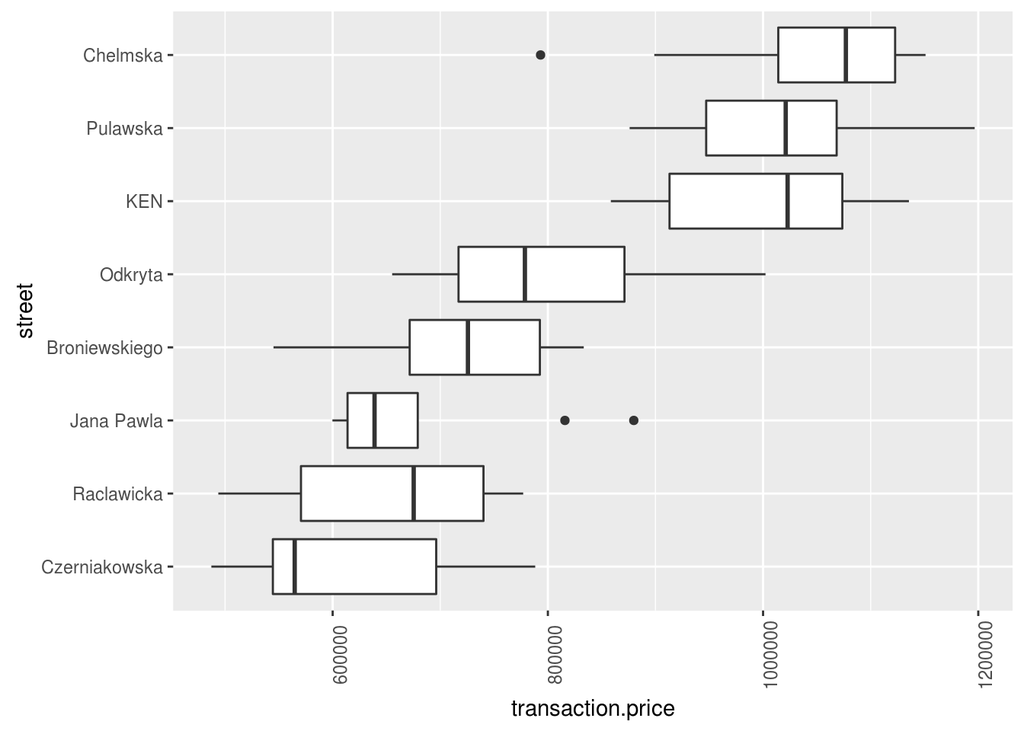

Wprowadźmy potrzebne oznaczenia oraz dodatkowe założenia.

Niech: $C \in \{1, 2, ..., k\}$ będzie zmienną grupującą, $y_{ij}$ będzie wartością $j$-tej obserwacji w $i$-tej grupie. Jako $n_i$ oznaczymy liczność $i$-tej grupy, zaś jako $n$ - liczność całej próby.

Dodatkowo założymy, że

$$y_{ij} \sim \mathcal{N} (\mu_i, \sigma^2), \;\;\;\;\; 1 \le i \le k, \;\;\;\;\; 1 \le j \le n_i \;\;\;\;\; \sum_{i = 1}^k n_i = n.$$

**Uwaga:** Zauważmy, że zakładamy równość wariancji we wszystkich grupach. To założenie wymaga dodatkowego sprawdzenia. Możemy do tego użyć np. testu Levene’a (`levene.test{Rcmdr}`).

```r
library(Rcmdr)
leveneTest(apartmentsSubset$transaction.price, apartmentsSubset$street)
```

```
## Levene's Test for Homogeneity of Variance (center = median)
##       Df F value Pr(>F)
## group  7  0.0973 0.9983
##       78
```

## Analiza wariancji

Analiza wariancji (ANOVA) to metoda, która służy do testowania hipotezy o równości średnich przy założeniu o równości wariancji. Formalnie – będziemy testować hipotezę zerową

$$H_0: \mu_1 = \mu_2 = \;... \;= \mu_k$$

przeciwko hipotezie alternatywnej

$$H_a: \exists_{i,j} \;\; \mu_i \neq \mu_j.$$

Parametryzując średnie

$$\mu_1 = \mu, \\ \mu_2 = \mu + \alpha_2, \\ ... \\ \mu_k = \mu + \alpha_k,$$

powyższy problem możemy przedstawić inczej

$$H_0: \alpha_2 = ... = \alpha_k = 0, \;\;\;\; H_a: \exists_i \;\; \alpha_i \neq 0.$$

Pierwszym krokiem będzie przekodowanie zmiennej objaśniającej $X$. Przedstawimy ją w postaci macierzy $n \times k$, w której pierwszą kolumną będzie stała, zaś następne kolumny będą reprezentować kolejne poziomy zmiennej $C$ (z pominięciem poziomu referencyjnego). Przykładowo wektor

$$C = \begin{bmatrix}
Jana Pawla \\
Jana Pawla \\
Chelmska \\
Chelmska \\
KEN
\end{bmatrix}$$
zapiszemy jako macierz

$$X = \begin{bmatrix}
1 & 0 & 0 \\
1 & 0 & 0 \\
1 & 1 & 0 \\
1 & 1 & 0 \\
1 & 0 & 1 \\
\end{bmatrix}$$

Wprowadźmy model

$$y = X \beta + \epsilon$$
dla wektora $\beta = (\mu, \alpha_2, \alpha_3, ... \alpha_k).$

Wówczas sprawdzenie prawdziwości $H_0$ sprowadza się do przetestowania łącznej hipotezy mówiącej o tym, że wszystkie współczynniki $\alpha_i$ wynoszą zero. Możemy to zrobić testem ilorazu wiarygodności.

### Test ilorazu wiarygodności

Niech

$$y = X \beta + \epsilon, \;\; \epsilon \sim \mathcal{N}(0, I_{n \times n})$$
dla $X$ i $\beta$ stałych.

Wówczas $y$ ma także rozkład normalny ze średnią $X\beta$ i wariancją $\sigma^2$. Zatem możemy napisać funkcję wiarygodności
$$L(\sigma, \beta |y) = \frac{1}{(2\pi\sigma^2)^{n/2}} \exp \left(- \frac{1}{2} \frac{RSS(\beta)}{\sigma^2}\right)$$
oraz jej logarytm

$$l(\sigma, \beta |y) = -\frac{n}{2}\log(2\pi) -\frac{n}{2}\log(\sigma^2) - \frac{RSS(\beta)}{2\sigma^2}.$$
Maksymalizując $l(\sigma, \beta |y)$ ze względu na $\sigma^2$ daje nam estymator

$$\hat{\sigma}^2 = \frac{RSS(\beta)}{n}.$$
Po wstawieniu estymatora do funkcji wiarygodności dostajemy
$$L(\hat{\sigma}^2, \hat{\beta} |y) \propto \left(\frac{RSS(\hat{\beta})}{n}\right)^{-n/2}.$$

Załóżmy, że testujemy hipotezę $H_0: \beta_q = \beta_{q+1} = ... = \beta_{q} = 0.$ Niech $RSS_X, RSS_W$ oznaczają sumę kwadratów reszt policzoną dla modelu pełnego i modelu z ograniczeniami. Wówczas iloraz wiarygodności
$$\frac{L(\hat{\sigma}_X, \hat{\beta}_X |y)}{L(\hat{\sigma}_W, \hat{\beta}_W |y)} = \left(\frac{RSS(\hat{\beta}_W)}{RSS(\hat{\beta}_X)}\right)^{n/2}$$
powinien być duży dla nieprawdziwej hipotezy zerowej.

Bardziej formalnie: można pokazać, że

$$T(\beta_W, \beta_X) = \frac{\frac{RSS(\beta_W) - RSS(\beta_X)}{p - q}}{\frac{RSS(\beta_X)}{n - p}}$$
ma rozkład $F$ (z odpowiednimi parametrami) i sprawdzenie prawdziwości $H_0$ sprowadza się do sprawdzenia wartości dystrybuanty rozkładu $F$ w punkcie $T(\hat{\beta}_W, \hat{\beta}_X)$.

### ANOVA na przykładzie cen mieszkań

Wracając do ANOVY i naszego przykładu. Możemy przetestować równość średnich na ulicach na co najmniej trzy sposoby.

**Sposób I**

```r
anova(lm(transaction.price ~ street, data = apartmentsSubset))
```

```
## Analysis of Variance Table
##
## Response: transaction.price
##           Df     Sum Sq    Mean Sq F value    Pr(>F)
## street     7 2.5568e+12 3.6526e+11  36.526 < 2.2e-16 ***
## Residuals 78 7.8000e+11 1.0000e+10
## ---
## Signif. codes:  0 '***' 0.001 '**' 0.01 '*' 0.05 '.' 0.1 ' ' 1
```

**Sposób II**

```r
summary(lm(transaction.price ~ street, data = apartmentsSubset))
```

```
##
## Call:
## lm(formula = transaction.price ~ street, data = apartmentsSubset)
##
## Residuals:
##     Min      1Q  Median      3Q     Max
## -256049  -71520  -16760   81539  199873
##
## Coefficients:
##                     Estimate Std. Error t value Pr(>|t|)
## (Intercept)           603147      28868  20.894  < 2e-16 ***
## streetRaclawicka       48330      44096   1.096  0.27644
## streetJana Pawla       76833      44096   1.742  0.08538 .
## streetBroniewskiego   114740      42817   2.680  0.00898 **
## streetOdkryta         200190      40032   5.001 3.44e-06 ***
## streetKEN             396607      44096   8.994 1.11e-13 ***
## streetPulawska        420753      44096   9.542 9.64e-15 ***
## streetChelmska        446128      38730  11.519  < 2e-16 ***
## ---
## Signif. codes:  0 '***' 0.001 '**' 0.01 '*' 0.05 '.' 0.1 ' ' 1
##
## Residual standard error: 1e+05 on 78 degrees of freedom
## Multiple R-squared:  0.7662, Adjusted R-squared:  0.7453
## F-statistic: 36.53 on 7 and 78 DF,  p-value: < 2.2e-16
```

**Sposób III**

```r
summary(aov(transaction.price ~ street, data = apartmentsSubset))
```

```
##             Df    Sum Sq   Mean Sq F value Pr(>F)
## street       7 2.557e+12 3.653e+11   36.53 <2e-16 ***
## Residuals   78 7.800e+11 1.000e+10
## ---
## Signif. codes:  0 '***' 0.001 '**' 0.01 '*' 0.05 '.' 0.1 ' ' 1
```

Zatem nie możemy powiedzieć, że średnie na różnych ulicach są równe.

## Testy post hoc

Testy *post hoc* wykonujemy, gdy ANOVA wskazuje na brak równości między średnimi. Pozwalają zidentyfikować, które średnie są różne statystycznie. Najczęściej testy *post hoc* liczą pewne statystyki dla wszystkich par grup.

Testów *post hoc* jest wiele. Część z nich zakłada, że wszystkie grupy są równoliczne. Przedstawimy test LSD Fishera, który nie posiada takiego założenia.

### Test LSD Fishera

Dla każdej pary grup $i, j$ liczymy statystykę $t$

$$t_{ij} = \frac{\mu_i - \mu_j}{s_{ij} \sqrt{\frac{1}{n_i} + \frac{1}{n_j}}}, \;\;\;\;\;\; s_{ij} = \sqrt{\frac{(n_i - 1)s_i^2 + (n_j - 1)s_j^2}{n_1 + n_2 - 2}}.$$
Łącznie przeprowadzonych jest ${k \choose 2}$ testów. W związku z tym stosujemy poprawkę na wielokrotne testowanie.

#### Wielokrotne testowanie

Załóżmy, że testujemy równocześnie $n$ hipotez, stosując ten sam poziom istotności $\alpha$. Wówczas

$$\mathbb{P}(odrzucilismy\; prawdziwa\; H_0) = 1 - \mathbb{P}(nie\; odrzucilismy\;zadnej \; prawdziwej\;\; H_0) =1 - (1 - \alpha)^n.$$

Dla $n = 20, \alpha = 0.05$ powyższe prawdopodobieństwo wynosi około $64\%$.

Żeby je zmniejszyć stosujemy poprawkę na wielokrotne testowanie. Przykładowo – poprawka Bonferroniego polega na podzieleniu poziomu istotności przez liczbę testowanych hipotez.

W naszym przykładzie dostajemy.

```r
library(agricolae)
lsdResult <- LSD.test(aov(transaction.price ~ street, data = apartmentsSubset),
                      trt = "street",
                      p.adj = "bonferroni")
lsdResult$groups
```

```
##             trt     means  M
## 1      Chelmska 1049275.4  a
## 2      Pulawska 1023900.4  a
## 3           KEN  999753.9  a
## 4       Odkryta  803337.6  b
## 5 Broniewskiego  717886.9 bc
## 6    Jana Pawla  679980.4 bc
## 7    Raclawicka  651477.0  c
## 8 Czerniakowska  603147.1  c
```

# Pytania badawcze

- Czy możemy stworzyć algorytm, którego wyniki będą zgodne (czyli otrzymane klastry będą rozłączne)?
- Czy jesteśmy w stanie w prosty sposób przedstawić zmiany w klastrach w zależności od przyjętego poziomu istotności/wiarygodności?

# Algorytm iteracyjnego zlepiania - pierwsze próby

## Podejście pierwsze: każdy vs. każdy

Pomysł: Załóżmy, że dla każdej pary testujemy hipotezę $H_0^{ij}: \mu_i = \mu_j$, stosując jednakowy test statystyczny. p-value dla wybranego testu to prawdopodobieństwo uzyskania wartości pewnej statystyki takiej, jak zaobserwowano w rzeczywistości przy założeniu prawdziwości hipotezy zerowej. Zatem para średnich, dla których p-value jest najwyższe powinna zostać złączona w jedną grupę.

```r
y = someResponse
class = someClass
numberOfClasses = numberOfClasses(class)

pValues = vector()

while (numberOfClasses > 1) {
    pairs = generateAllPossiblePairs(class)
    maxPValue = 0
    toBeMerged = vector()
    for (pair in pairs) {
        if (maxPValue > pValueTTest(pair)) {
            maxPValue = pValueTTest(pair)
            toBeMerged = pair
        }
    }
    pValues = append(maxPValue, pValues)
    class = mergeClasses(class, pair)
    numberOfClasses = numberOfClasses - 1
}
```

Liczba policzonych statystyk $t$/$p$-value w całym algorytmie: $\sum_{i = 1}^k {i \choose 2}$ (dużo – sześciennie).

Plusy:

- dostajemy hierarchiczną strukturę klastrów.

Minusy:

- wiele razy liczymy to samo,
- porównujemy nadmiarową ilość par.

Obserwacja: W pojedynczym kroku chcemy połączyć jedynie te średnie, które są wystarczająco blisko.

## Podejście drugie: każdy vs. kolejny

Pomysł: uszereguj grupy wg rosnącej średniej. W każdym kroku porównuj tylko dwie kolejne pary.

```r
y = someResponse
class = sort(someClass, y)
numberOfClasses = numberOfClasses(class)

pValues = vector()
logLiks = vector()

while (numberOfClasses > 1) {
    pairs = generateSubsequentPairs(class)
    model = lm(y ~ class)
    logLiks = append(logLik(model), logLiks)
    maxPValue = 0
    toBeMerged = vector()
    for (pair in pairs) {
        if (maxPValue > pValueTTest(model, pair)) {
            maxPValue = pValueTTest(model, pair)
            toBeMerged = pair
        }
    }
    pValues = append(maxPValue, pValues)
    class = mergeClasses(class, pair)
    numberOfClasses = numberOfClasses - 1
}
```

Liczba policzonych statystyk $t$/$p$-value w całym algorytmie: $\sum_{i = 1}^{k - 1} i$ (kwadratowo).

Plusy:

- dostajemy hierarchiczną strukturę klastrów,
- w każdym testujemy mniej niż $k$ hipotez.

Minusy:

- w każdym kroku na nowo liczymy model pomniejszony o jeden parametr.

Implementacja: kontrasty!

Pytania: Czy możemy policzyć nowe p-value bez ponownego wyliczania modelu? Czy możemy iteracyjnie liczyć wiarygodność, korzystając jedynie z wartości poprzedniej wiarygodności oraz informacji dotyczącej łącząnych grup?

## Testy

### Losowe dane

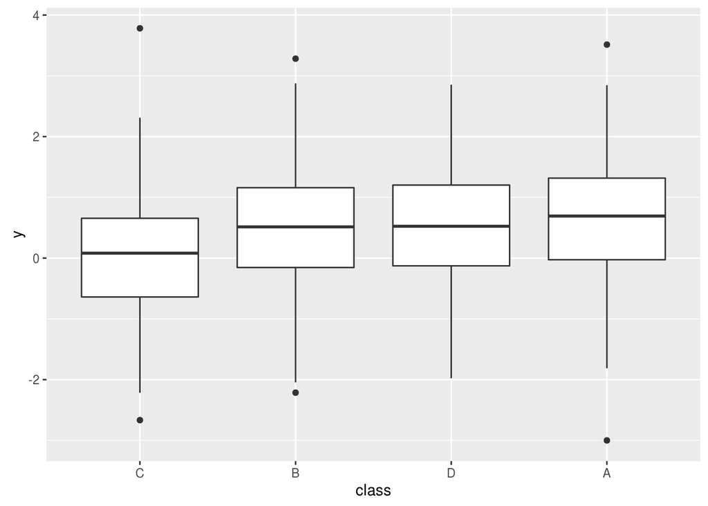

```r
k <- 4; N <- 1000
myData <- generateSample(N, k)
myData %>% ggplot() + geom_boxplot(aes(y = y, x = class, group = class))
```

```r
merging <- mergeFactors(myData$y, myData$class)
merging$mergingList
```

```
## [[1]]
## [1] "B" "D"
##
## [[2]]
## [1] "BD" "A"
##
## [[3]]
## [1] "C"   "BDA"
```

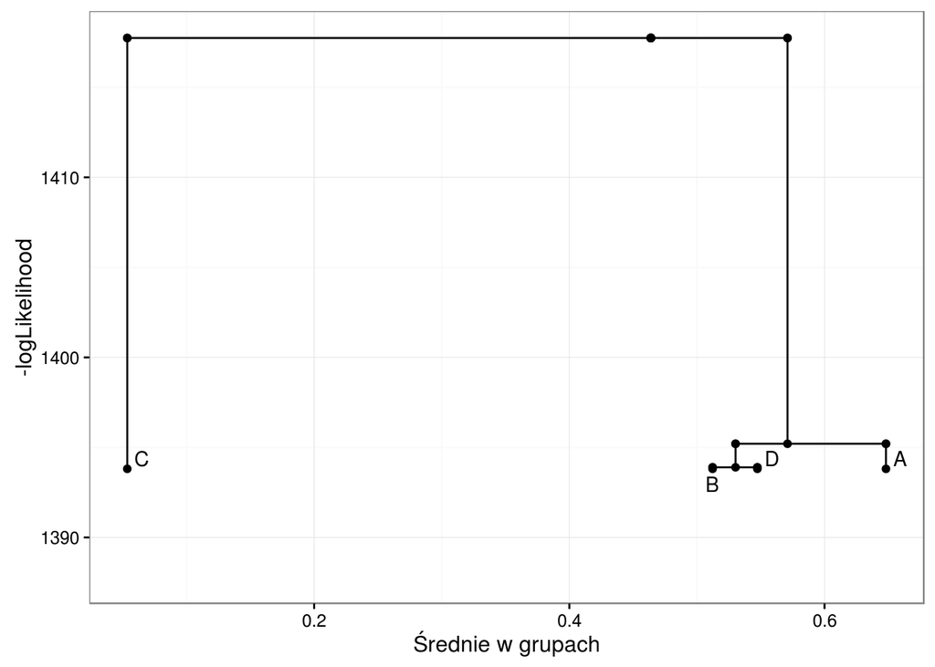

[figure not shown]

```r
plotTree(merging)
```

### Dane rzeczywiste

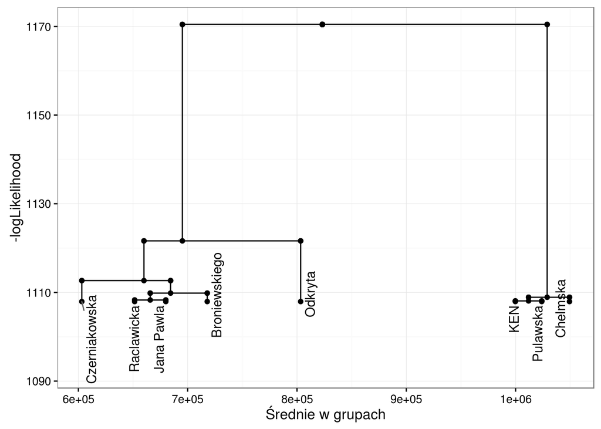

```r
apartmentsMerged <- mergeFactors(apartmentsSubset$transaction.price, apartmentsSubset$street)
plotTree(apartmentsMerged, rotate = 90)
```

# Inne rozwiązania

## Delete or Merge Regressors (DMR)

Autor: Agnieszka Prochenka

W uproszczeniu: dla każdej pary grup $i, j$ policz statystykę $t$ dla hipotezy $H_0: \mu_i = \mu_j$. Przyjmij macierz $[t_{ij}]_{i,j}$ jako macierz odległości pomiędzy grupami. Przeprowadź klastrowanie hierarchiczne metodą *complete linkage*.

Liczba policzonych statystyk $t$ w całym algorytmie: $k^2$.

# Co dalej?

- zoptymalizować przejście pomiędzy kolejnymi modelami,
- rozszerzyć klastrowanie na modele zagnieżdżone,
- poprawić rysowanie drzewa (szczególnie dla dużych nazw),
- umożliwić edycję osi z poziomu użytkownika,
- przeciążyć funkcję `plot`.

# Literatura

- ‘Analiza danych z programem R: modele liniowe z efektami stałymi, losowymi i mieszanymi’ Przemysław Biecek,
- ‘Delete or Merge Regressors algorithm’ Agnieszka Prochenka,
- ‘Clustering in an Object-Oriented Environment’, Anja Struyf, Mia Hubert, Peter J. Rousseeuw.